# Titanic_report

## O Danych

Dane o pasażerach Titanica

Zbiór danych zawiera informacje o pasażerach RMS Titanic, który zatonął 15 kwietnia 1912 roku po zderzeniu z górą lodową. Dane obejmują takie atrybuty jak klasa podróży, wiek, płeć, liczba rodzeństwa/małżonków na pokładzie, liczba rodziców/dzieci na pokładzie, cena biletu oraz miejsce zaokrętowania.

Zbiór zawiera także informację o tym, czy pasażer przeżył katastrofę.

Titanic przewoził ponad 2,200 osób, z czego ponad 1,500 zginęło, co czyni tę katastrofę jedną z najbardziej tragicznych w historii morskiej.

Kolumny:

- **pclass** - Klasa biletu
- **survived** - Czy pasażer przeżył katastrofę
- **name** - Imię i nazwisko pasażera
- **sex** - Płeć pasażera
- **age** - Wiek pasażera
- **sibsp** - Liczba rodzeństwa/małżonków na pokładzie
- **parch** - Liczba rodziców/dzieci na pokładzie
- **ticket** - Numer biletu
- **fare** - Cena biletu
- **cabin** - Numer kabiny
- **embarked** - Port, w którym pasażer wszedł na pokład (C = Cherbourg, Q = Queenstown, S = Southampton)
- **boat** - Numer łodzi ratunkowej
- **body** - Numer ciała (jeśli pasażer nie przeżył i ciało zostało odnalezione)
- **home.dest** - Miejsce docelowe

|  | pclass | survived | name | sex | age | sibsp | parch | ticket | fare | cabin | embarked | boat | body | home.dest |
| --- | --- | --- | --- | --- | --- | --- | --- | --- | --- | --- | --- | --- | --- | --- |
| 0 | 1.0 | 1.0 | Allen, Miss. Elisabeth Walton | female | 29.0000 | 0.0 | 0.0 | 24160 | 211.3375 | B5 | S | 2 | NaN | St Louis, MO |
| 1 | 1.0 | 1.0 | Allison, Master. Hudson Trevor | male | 0.9167 | 1.0 | 2.0 | 113781 | 151.5500 | C22 C26 | S | 11 | NaN | Montreal, PQ / Chesterville, ON |
| 2 | 1.0 | 0.0 | Allison, Miss. Helen Loraine | female | 2.0000 | 1.0 | 2.0 | 113781 | 151.5500 | C22 C26 | S | NaN | NaN | Montreal, PQ / Chesterville, ON |
| 3 | 1.0 | 0.0 | Allison, Mr. Hudson Joshua Creighton | male | 30.0000 | 1.0 | 2.0 | 113781 | 151.5500 | C22 C26 | S | NaN | 135.0 | Montreal, PQ / Chesterville, ON |
| 4 | 1.0 | 0.0 | Allison, Mrs. Hudson J C (Bessie Waldo Daniels) | female | 25.0000 | 1.0 | 2.0 | 113781 | 151.5500 | C22 C26 | S | NaN | NaN | Montreal, PQ / Chesterville, ON |
| ... | ... | ... | ... | ... | ... | ... | ... | ... | ... | ... | ... | ... | ... | ... |
| 1305 | 3.0 | 0.0 | Zabour, Miss. Thamine | female | NaN | 1.0 | 0.0 | 2665 | 14.4542 | NaN | C | NaN | NaN | NaN |
| 1306 | 3.0 | 0.0 | Zakarian, Mr. Mapriededer | male | 26.5000 | 0.0 | 0.0 | 2656 | 7.2250 | NaN | C | NaN | 304.0 | NaN |
| 1307 | 3.0 | 0.0 | Zakarian, Mr. Ortin | male | 27.0000 | 0.0 | 0.0 | 2670 | 7.2250 | NaN | C | NaN | NaN | NaN |
| 1308 | 3.0 | 0.0 | Zimmerman, Mr. Leo | male | 29.0000 | 0.0 | 0.0 | 315082 | 7.8750 | NaN | S | NaN | NaN | NaN |
| 1309 | NaN | NaN | NaN | NaN | NaN | NaN | NaN | NaN | NaN | NaN | NaN | NaN | NaN | NaN |

1310 rows × 14 columns

[figure not shown]

# Ogólne rozeznanie danych.

|  | pclass | survived | name | sex | age | sibsp | parch | ticket | fare | cabin | embarked | boat | body | home.dest |
| --- | --- | --- | --- | --- | --- | --- | --- | --- | --- | --- | --- | --- | --- | --- |
| 701 | 3.0 | 0.0 | Calic, Mr. Petar | male | 17.0 | 0.0 | 0.0 | 315086 | 8.6625 | NaN | S | NaN | NaN | NaN |
| 994 | 3.0 | 0.0 | Mardirosian, Mr. Sarkis | male | NaN | 0.0 | 0.0 | 2655 | 7.2292 | F E46 | C | NaN | NaN | NaN |
| 350 | 2.0 | 1.0 | Brown, Miss. Edith Eileen | female | 15.0 | 0.0 | 2.0 | 29750 | 39.0000 | NaN | S | 14 | NaN | Cape Town, South Africa / Seattle, WA |
| 986 | 3.0 | 0.0 | Maenpaa, Mr. Matti Alexanteri | male | 22.0 | 0.0 | 0.0 | STON/O 2. 3101275 | 7.1250 | NaN | S | NaN | NaN | NaN |
| 409 | 2.0 | 0.0 | Fox, Mr. Stanley Hubert | male | 36.0 | 0.0 | 0.0 | 229236 | 13.0000 | NaN | S | NaN | 236.0 | Rochester, NY |
| 917 | 3.0 | 1.0 | Karun, Mr. Franz | male | 39.0 | 0.0 | 1.0 | 349256 | 13.4167 | NaN | C | 15 | NaN | NaN |
| 905 | 3.0 | 1.0 | Jonsson, Mr. Carl | male | 32.0 | 0.0 | 0.0 | 350417 | 7.8542 | NaN | S | 15 | NaN | NaN |
| 1117 | 3.0 | 0.0 | Pekoniemi, Mr. Edvard | male | 21.0 | 0.0 | 0.0 | STON/O 2. 3101294 | 7.9250 | NaN | S | NaN | NaN | NaN |
| 1168 | 3.0 | 0.0 | Sadowitz, Mr. Harry | male | NaN | 0.0 | 0.0 | LP 1588 | 7.5750 | NaN | S | NaN | NaN | NaN |
| 344 | 2.0 | 1.0 | Bentham, Miss. Lilian W | female | 19.0 | 0.0 | 0.0 | 28404 | 13.0000 | NaN | S | 12 | NaN | Rochester, NY |

# Ogólne informacje o kolumnach

|  | Column | Data Type | Non-Null Count | Null Count |
| --- | --- | --- | --- | --- |
| 0 | pclass | float64 | 1309 | 1 |
| 1 | survived | float64 | 1309 | 1 |
| 2 | name | object | 1309 | 1 |
| 3 | sex | object | 1309 | 1 |
| 4 | age | float64 | 1046 | 264 |
| 5 | sibsp | float64 | 1309 | 1 |
| 6 | parch | float64 | 1309 | 1 |
| 7 | ticket | object | 1309 | 1 |
| 8 | fare | float64 | 1308 | 2 |
| 9 | cabin | object | 295 | 1015 |
| 10 | embarked | object | 1307 | 3 |
| 11 | boat | object | 486 | 824 |
| 12 | body | float64 | 121 | 1189 |
| 13 | home.dest | object | 745 | 565 |

# Wartości brakujące

|  | Column | Wartości brakujące |
| --- | --- | --- |
| 0 | pclass | 1 |
| 1 | survived | 1 |
| 2 | name | 1 |
| 3 | sex | 1 |
| 4 | age | 264 |
| 5 | sibsp | 1 |
| 6 | parch | 1 |
| 7 | ticket | 1 |
| 8 | fare | 2 |
| 9 | cabin | 1015 |
| 10 | embarked | 3 |
| 11 | boat | 824 |
| 12 | body | 1189 |
| 13 | home.dest | 565 |

### Co do wieku nie jestem zaskoczony, że brakuje wartości, ale o tak dużej liczbie **nie** odnalezionych ciał nawet nie śniłem.

### Zapewne duża cześć ciał odnalezionych to te które dodryfowały do brzegu bo sam **Titanic** rozbił się nie aż tak daleko od lądu.

[figure not shown]

## Do zdarzenia doszło ok 700km od brzegu.

|  | pclass | survived | name | sex | age | sibsp | parch | ticket | fare | cabin | embarked | boat | body | home.dest |
| --- | --- | --- | --- | --- | --- | --- | --- | --- | --- | --- | --- | --- | --- | --- |

Tu bez zaskoczeń, ale zawsze warto się upewnić.

# Analiza poszczególnych zmiennych.

### Tutaj skupię się na kilku rzeczach mianowinie na tym kogo najwięcej udało się uratować z podziałem na klasę, płeć oraz wiek.

#### Zobaczymy co mówią nam dane i czy rzeczywiście sytuacja wyglądała jak w filmie, czyli najpierw kobiety i dzieci.

|  | pclass | survived | name | sex | age | sibsp | parch | ticket | fare | cabin | embarked | boat | body | home.dest |
| --- | --- | --- | --- | --- | --- | --- | --- | --- | --- | --- | --- | --- | --- | --- |
| 0 | 1.0 | 1.0 | Allen, Miss. Elisabeth Walton | female | 29.0000 | 0.0 | 0.0 | 24160 | 211.3375 | B5 | S | 2 | NaN | St Louis, MO |
| 1 | 1.0 | 1.0 | Allison, Master. Hudson Trevor | male | 0.9167 | 1.0 | 2.0 | 113781 | 151.5500 | C22 C26 | S | 11 | NaN | Montreal, PQ / Chesterville, ON |
| 2 | 1.0 | 0.0 | Allison, Miss. Helen Loraine | female | 2.0000 | 1.0 | 2.0 | 113781 | 151.5500 | C22 C26 | S | NaN | NaN | Montreal, PQ / Chesterville, ON |
| 3 | 1.0 | 0.0 | Allison, Mr. Hudson Joshua Creighton | male | 30.0000 | 1.0 | 2.0 | 113781 | 151.5500 | C22 C26 | S | NaN | 135.0 | Montreal, PQ / Chesterville, ON |
| 4 | 1.0 | 0.0 | Allison, Mrs. Hudson J C (Bessie Waldo Daniels) | female | 25.0000 | 1.0 | 2.0 | 113781 | 151.5500 | C22 C26 | S | NaN | NaN | Montreal, PQ / Chesterville, ON |
| ... | ... | ... | ... | ... | ... | ... | ... | ... | ... | ... | ... | ... | ... | ... |
| 1301 | 3.0 | 0.0 | Youseff, Mr. Gerious | male | 45.5000 | 0.0 | 0.0 | 2628 | 7.2250 | NaN | C | NaN | 312.0 | NaN |
| 1304 | 3.0 | 0.0 | Zabour, Miss. Hileni | female | 14.5000 | 1.0 | 0.0 | 2665 | 14.4542 | NaN | C | NaN | 328.0 | NaN |
| 1306 | 3.0 | 0.0 | Zakarian, Mr. Mapriededer | male | 26.5000 | 0.0 | 0.0 | 2656 | 7.2250 | NaN | C | NaN | 304.0 | NaN |
| 1307 | 3.0 | 0.0 | Zakarian, Mr. Ortin | male | 27.0000 | 0.0 | 0.0 | 2670 | 7.2250 | NaN | C | NaN | NaN | NaN |
| 1308 | 3.0 | 0.0 | Zimmerman, Mr. Leo | male | 29.0000 | 0.0 | 0.0 | 315082 | 7.8750 | NaN | S | NaN | NaN | NaN |

1046 rows × 14 columns

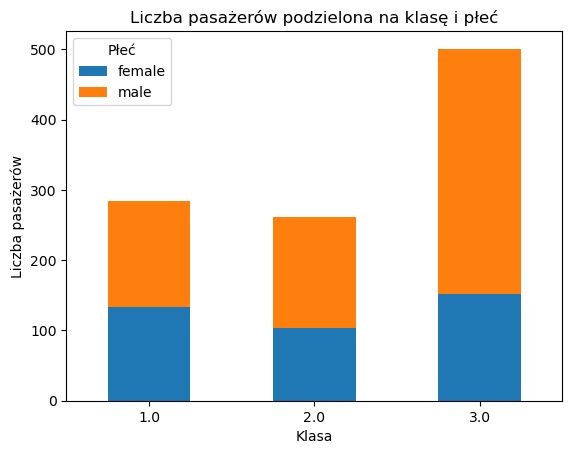

Bardzo przydatny wykres idealnie obrazowuję podział pasażerów na klasę i płeć

Jak widać najwięcej osób podróżowało trzecią klasą co nie jest zaskoczeniem, zaskoczeniem jest natomiat, że pierwsza i druga klasa są do siebie zbliżone, a zakładałem, że pierwszej klasy będzie znacznie mniej od reszty.

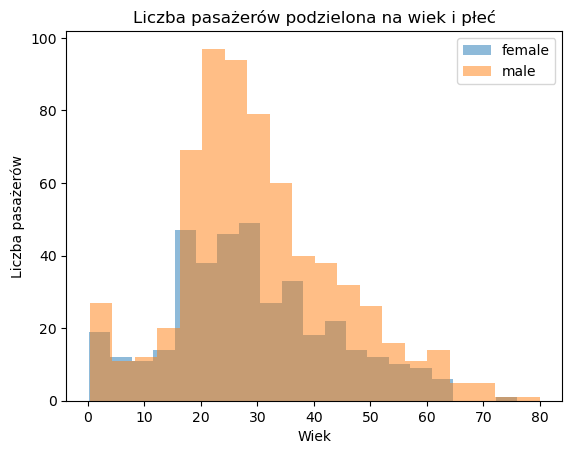

#### I oto naprawdę wiele nam mówiący wykres w dalszej perspektywie, bo zaraz zobaczymy ile osób przeżyło jakiej było płci oraz w jakim byli wieku.

Możemy też zauważyć iż mężczyzn było znacznie więcej niż kobiet, a najliczniejszy przedział wiekowy to 20-30lat, potem osoby w wieku średnim, dzieci i na końcu seniorzy.

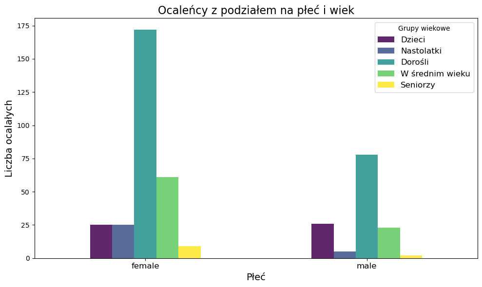

Jak widać na wykresie powyżej uratowano znacznie więcej kobiet i dzieci od mężczyzn nie licząc chłopców.

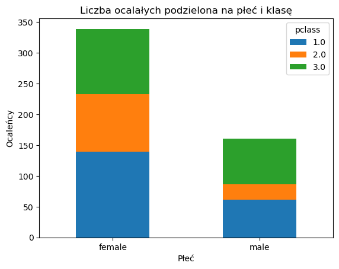

#### Bez zaskoczeń najwięcej ocalałych to kobiety z każdej klasy.

## Podsumowanie:

- Najwięcej pasażerów na statku podróżowało klasą trzecią i byli to w większości mężczyźni,
- Najliczniejszy przedział wiekowy to 20-30lat, potem osoby w wieku średnim, dzieci i seniorzy,
- Uratowano znacznie więcej kobiet od mężczyzn w prawie każdym przedziale wiekowym,
- Najwięcej ocaleńców to kobiety i dzieci z każdej klasy potwierdziła się moja hipoteza.

# Poszukiwanie korelacji między zmiennymi.

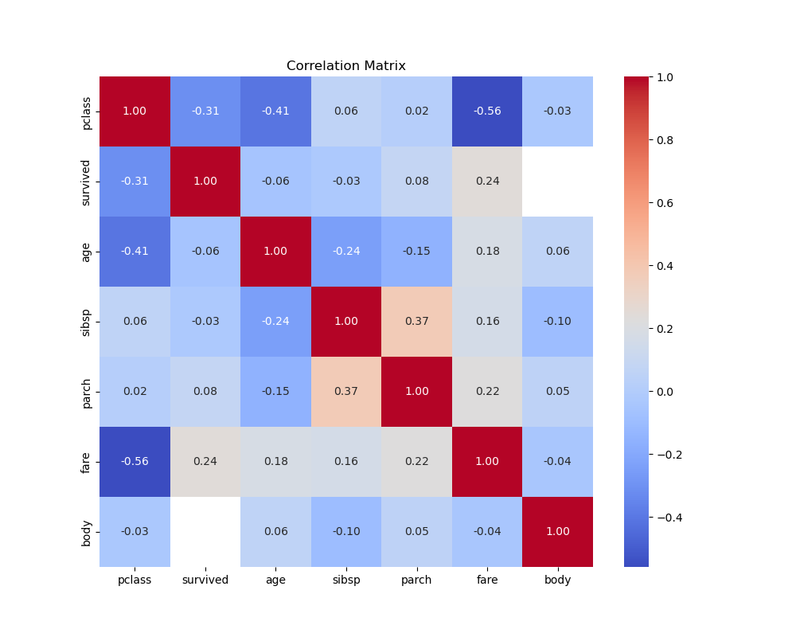

## Podsumowanie:

Nie ma jednoznacznych korelacji między zmiennymi na macierzu, takich jak np. ocaleńcy z podziałem na płeć. Raczej nie ma się tu doszukiwać, można zaznaczyć iż istnieje lekko odwrócona korelacja między ceną biletu a klasą co nie jest zaskoczeniem.

# Poszukiwanie wartości odstających.

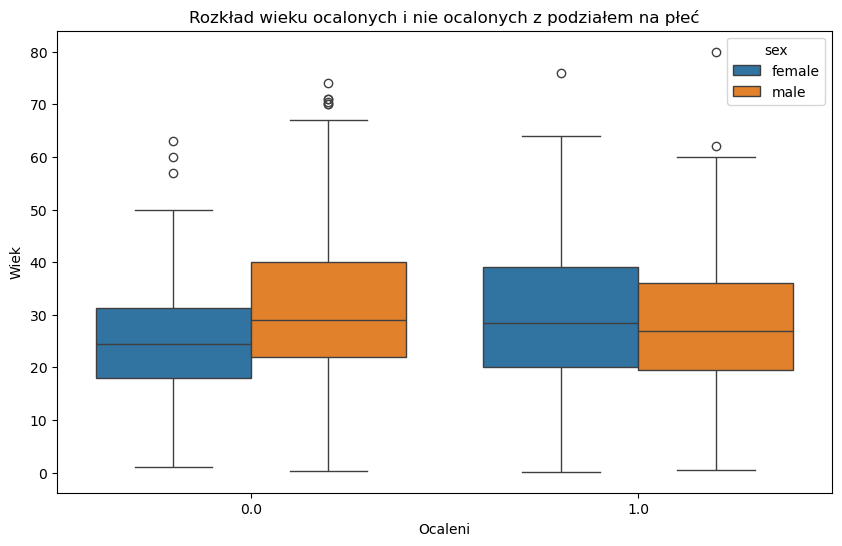

## Podsumowanie:

# Podsumowanie i konkluzja.